# Final Project - Violence against women in Nigeria

Findings from the 2018 Demographic and Health Survey

Julia Waibel

2023-02-14

# Domestic violence

Across the 41,821 surveyed women (age 15 to 49), 10,678 were selected for the domestic violence interview, and 31.6% experienced domestic violence.

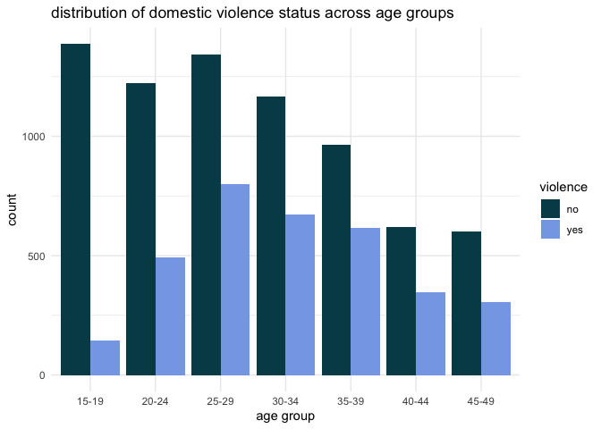

Presence of domestic violence among women by age group

Figure 1 shows the prevalence of domestic violence against Nigerian women across different age groups.

The mean age of women not having experienced domestic violence is 29 (Standard Deviation 9.3) years. Hence, they are younger than the group of women who are victims of domestic violence (mean age 31.7, Standard Deviation 8.1 years).

### **Experiences of violence differs by region**

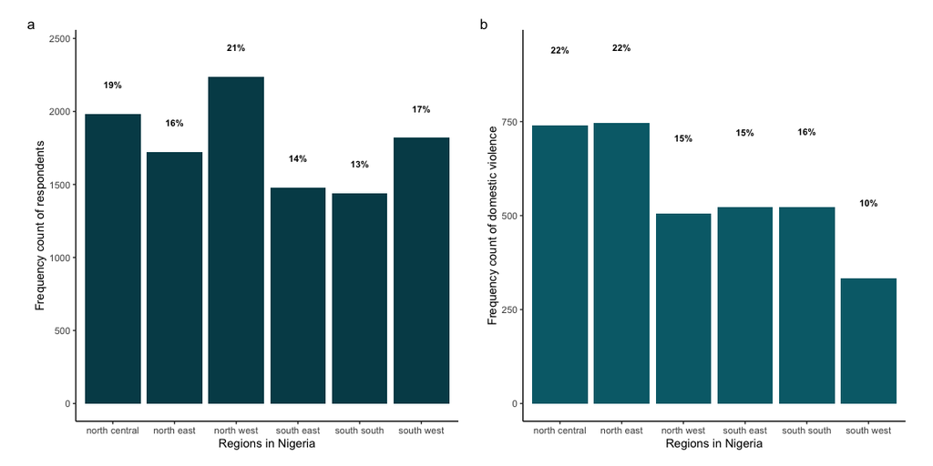

Distribution of regions represented

Figure 2 consists of two plots with a) showing the respresentativeness of regions in the sample of Nigerian women responding to the violence module, and b) showing the regions the women reporting to have experienced domestic violence are from. Comparing those two plots might stress differences in prevalence of domestic violence across regions in Nigeria.

### **Perpetrator**

In this sample, across the 409 women responding to the question, the victim´s mother (44%) seem to be the person mostly responsible for domestic violence

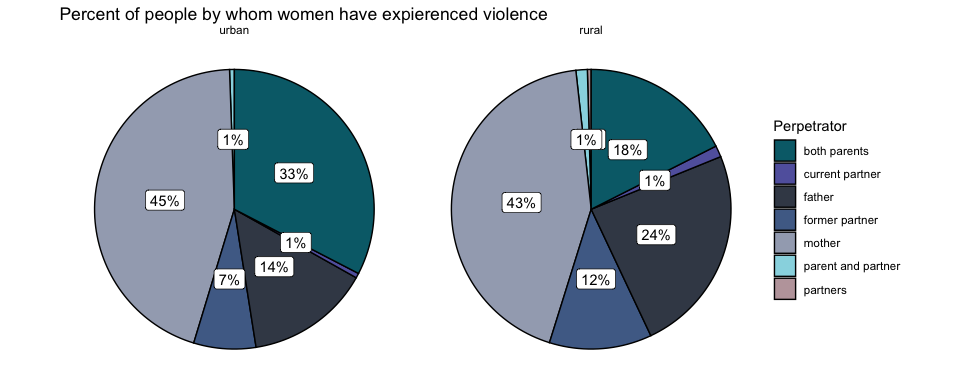

Perpetrator

Figure 3 shows differences between urban and rural areas with regards to the person who hurt the women in the survey most. In both regions, the mother remains to be the most frequent perpetrator, followed by both parents, and the father in urban and rural areas, respectively.

# Female genital mutilation

In this sample, 58% of women have ever heard of female circumcision, and 18% reported to be circumcised.

In the majority of cases, the person who has performed the circumcision, is a “traditional circumciser” (73%). Significantly less women reported to have been circumcised by a trained nurse/midwife (9%), a traditional birth attendant (9%), or a doctor (1%).

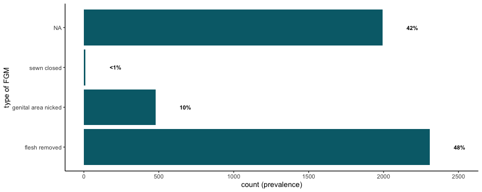

Types of circumcision

Figure 4 shows the prevalence of different types of female genital mutilation. In most cases of valid answers regarding type of circumcision, the flesh was removed (48%).

### **Age at circumcision among Nigerian women**

Many women reported female genital mutilation happening to them during infancy without specifying the age (67%). However, among those reporting it, the age of circumcision acts ranges from 0 to 46 years.